# Exploring Relationships Between Extreme Poverty Rates and Inflation Rates in the World

Author

Tarj Mecwan, Bernice Lau, Rachel Hartfelder, Haley Tran

```r
library(bibtex)
library(tidyverse)
library(knitr)
library(viridis)
library(kableExtra)
library(broom)
```

# The Data

```r
poverty <- read_csv("data/poverty.csv")
inflation <- read_csv("data/inflation.csv")
```

In this analysis, we will explore the relationships between extreme poverty rates and inflation rates around the world. We use data from the Poverty and Inequality Platform of The World Bank (Bank 2022) and The World Bank Group (Bank 2025), specifically the “Extreme Poverty Rate, less than $2.15/day” and “Inflation, annual %” data sets curated by Gapminder (Gapminder 2025).

The poverty dataset contains information on the extreme poverty rate for countries from 1800 to 2100, where a proportion of the population makes less than $2.15/day, according to Gapminder (Gapminder 2015). Each country represents one observation and each column represents one year.

The inflation dataset contains information on the inflation rate for countries from 1961 to 2023. Inflation indicates the rate of change of prices in the economy and is “measured by the annual growth rate of the GDP implicit deflator”, which is the “ratio of GDP in current local currency to GDP in constant local currency”, according to Gapminder (Gapminder 2025). GDP, otherwise known as Gross Domestic Product, is the “standard measure of the value added created through the production of goods and services in a country during a certain period”, as stated by The Organisation for Economic Cooperation and Development (OECD 2022). Each country represents one observation and each column represents one year.

# Data Cleaning Process

Data cleaning is a crucial step in ensuring that our analysis is based on accurate and meaningful data. Since the datasets contain economic indicators recorded across multiple years for different countries, we followed a structured cleaning process to prepare our data for analysis.

The original data sets contained economic data spanning different time periods, with some variables recorded in years that were not present in the other dataset. To maintain consistency, we filtered both datasets to include only the overlapping years, 1961 to 2023. This step ensures that we are analyzing the relationship between extreme poverty rates and inflation rates over a common time period without introducing missing values due to mismatched years.

Secondly, the data sets were structured in a wide format, where each year was a separate column. For ease of analysis and visualization, we transformed them into a long format so that the year columns were combined into a single variable. This conversion was necessary to perform operations like merging datasets and running regression models.

Once the data sets were in long format, we merged them together into one data set and deleted rows with missing values, such that each country-year pair has both inflation and poverty data available. This decision helps maintain data integrity and prevents bias introduced by missing observations. While other imputation techniques (such as mean or median substitution) could have been used, we opted for deletion to maintain the accuracy of our statistical analysis and avoid introducing artificial trends.

```r
# Filter the datasets to include only the overlapping years (1961 to 2023) and
# Pivot the year columns to a single column in both datasets
inflation_filtered_long <- inflation |>
  select(country, `1961`:`2023`) |>
  pivot_longer(cols = `1961`:`2023`,
               names_to = "year",
               values_to = "inflation_rate") |>
  mutate(year = as.numeric(year))

poverty_filtered_long <- poverty |>
  select(country, `1961`:`2023`) |>
  pivot_longer(cols = `1961`:`2023`,
               names_to = "year",
               values_to = "poverty_rate") |>
  mutate(year = as.numeric(year))

# Join the datasets on country and year, drop missing values, fix variable types
poverty_inflation_data <- inflation_filtered_long |>
  inner_join(poverty_filtered_long, by = c("country", "year")) |>
  drop_na() |>
  mutate(inflation_rate = gsub("\u2212", "-", inflation_rate)) |>
  mutate(inflation_rate = ifelse(
    grepl("k", inflation_rate, ignore.case = TRUE),
    as.numeric(gsub("k", "", inflation_rate, ignore.case = TRUE)) * 1000,
    as.numeric(inflation_rate)))
```

The combined dataset contains 10,163 observations and 4 variables with information about the annual inflation and extreme poverty rates for 190 countries from 1961 to 2023. Each country-year pair represents one observation.

```r
# Total observations and variables
nrow(poverty_inflation_data)
ncol(poverty_inflation_data)

# Number of countries
length(unique(poverty_inflation_data$country))

# Year range
min(poverty_inflation_data$year, na.rm = TRUE)
max(poverty_inflation_data$year, na.rm = TRUE)
```

[output not shown]

# Hypothesis

We hypothesize that there will be a nonlinear relationship between inflation rates and poverty rates in the world. Intuitively, frequent fluctuations in inflation rates will be associated with higher poverty rates, as economic instability disproportionately affects people of lower incomes. As such, we think that a linear model will not be sufficient in evaluating the relationship between poverty rates and inflation. We further hypothesize that there will be regional or country-specific patterns because economic structures, government policies, and external factors such as tariffs and diplomatic conflict would likely affect the relationship between inflation and poverty differs across global regions, which would result in a nonlinear relationship between inflation and poverty rates in the world.

# Linear Regression

## Data Visualization

Inflation rates can vary widely, with some countries experiencing very low rates and others experiencing extremely high rates. When we initially plotted the graph directly using the data from the joined data set, the distribution was strongly right-skewed, with most of the points located along the y-axis. As a result, we applied a log transformation to the inflation rates to spread out the values more evenly. By applying a log transformation, we compress the range of inflation rates, making it easier to visualize and interpret the relationship between inflation rate and poverty rate.

The scatterplot below shows the relationship between the log-transformed inflation rate and the poverty rate, where each point represents an observation of inflation rate and poverty rate for a country in a year within 1961 to 2023.

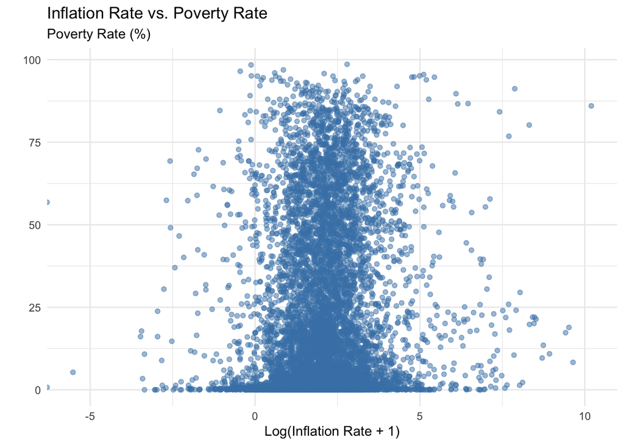

Relationship between log-transformed inflation rate and extreme poverty rate from 1961 to 2023.

```r
# Scatter plot of inflation rate vs. poverty rate
ggplot(data = poverty_inflation_data,
       mapping = aes(x = log1p(inflation_rate),
                     y = poverty_rate)) +
  geom_point(alpha = 0.5, color = "steelblue") +
  labs(
    title = "Inflation Rate vs. Poverty Rate",
    subtitle = "Poverty Rate (%)",
    x = "Log(Inflation Rate + 1)",
    y = "") +
  theme_minimal()
```

The scatter plot of the log-transformed inflation rate versus the poverty rate reveals a concentration of data points around x = 2 on the log-transformed scale. This indicates that many countries have an inflation rate close to 7%, since ln(8) is approximately 2. This implies that moderate inflation rates (around 7%) are common across the dataset. The normally distributed spread of points shows that, even with similar inflation rates, countries can experience a wide range of poverty rates, highlighting the complexity of the relationship between these two variables.

Let’s explore how the relationship between inflation rate and poverty rate changes over time. The scatterplot below illustrates the change in relationship between log-transformed average global inflation rate and average global poverty rate from 1961 to 2023, where each point represents the log-transformed average global inflation rate and average global poverty rate for a specific year. As in the graph above, we applied a log transformation to the inflation rates to spread out the values for clearer visualization.

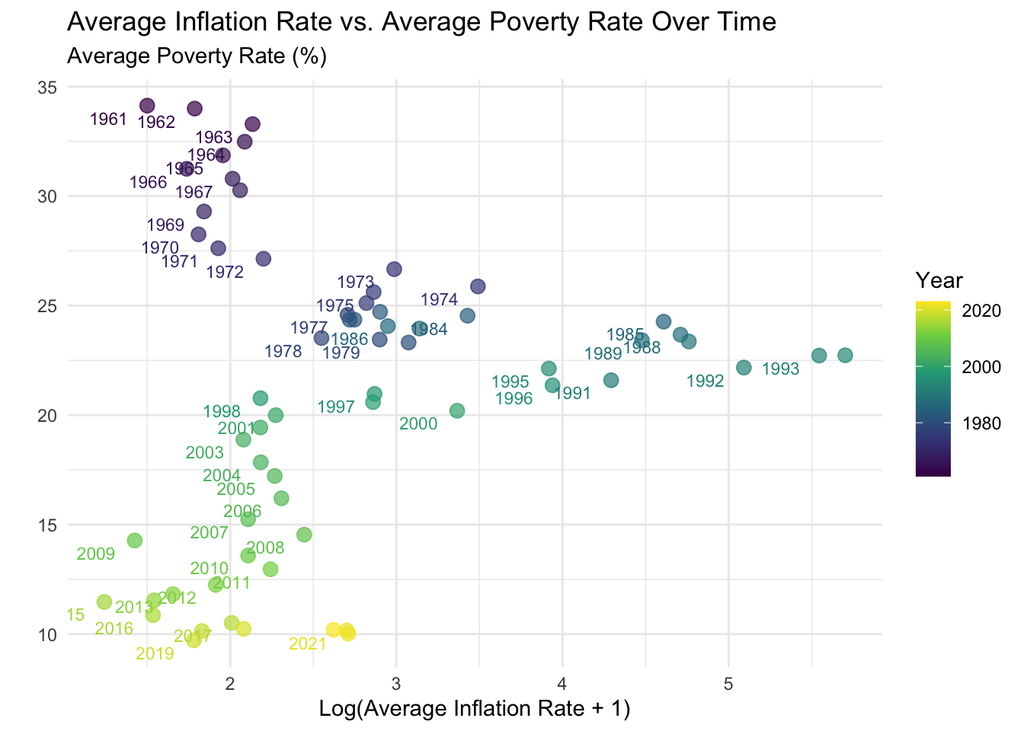

Change in relationship between log-transformed average global inflation rate and average global poverty rate from 1961 to 2023.

```r
# Aggregate data to show average values per year
aggregated_data <- poverty_inflation_data |>
  group_by(year) |>
  summarize(avg_inflation_rate = mean(inflation_rate, na.rm = TRUE),
            avg_poverty_rate = mean(poverty_rate, na.rm = TRUE))

# Plot of average inflation rate vs. average poverty rate over time
ggplot(data = aggregated_data,
       mapping = aes(x = log1p(avg_inflation_rate),
                     y = avg_poverty_rate,
                     color = year)) +
  geom_point(alpha = 0.7, size = 3) +
  geom_text(aes(label = year),
            hjust = 1.5,
            vjust = 1.5,
            size = 3,
            check_overlap = TRUE) +
  scale_color_viridis_c() +
  labs(
    title = "Average Inflation Rate vs. Average Poverty Rate Over Time",
    subtitle = "Average Poverty Rate (%)",
    x = "Log(Average Inflation Rate + 1)",
    y = "",
    color = "Year") +
  theme_minimal()
```

From this graph, we observe that 1961-1980 is characterized by low to moderate average global inflation rates, accompanied by high average global poverty rates. This suggests that despite relatively stable inflation, poverty remained a significant issue globally. 1980-2000 had moderate to high average global inflation rates, while average global poverty rates decreased to moderate levels, indicating a period of economic volatility with higher inflation and some progress in reducing poverty. Lastly, 2000-2023 shows low to moderate levels of average global inflation, with average global poverty rates further decreasing to low to moderate levels. This suggests improved economic stability and continued progress in poverty reduction.

## Linear Regression Model

To explore the relationship between inflation rate and extreme poverty rate, we fit the variables to a linear regression model. We define the explanatory variable (X) to be the inflation rate and the response variable (Y) to be the poverty rate.

The population model is expressed as:

where:

- $Y$ = Observed poverty rate
- $X$ = Log-transformed inflation rate
- $\beta_0$ = Intercept (poverty rate when inflation is near zero)
- $\beta_1$ = Slope (expected change in poverty rate for a one-unit increase in log-transformed inflation)
- $\epsilon$ = Error term

The intercept represents the predicted extreme poverty rate when the inflation rate is close to zero. This baseline provides insight into poverty conditions in relatively stable economies.

The slope represents the expected change in the extreme poverty rate for a one-unit increase in the log-transformed inflation rate. A positive slope suggests that higher inflation is associated with increased poverty, likely due to rising costs of living and reduced purchasing power. Conversely, a negative slope would indicate that higher inflation correlates with lower poverty, possibly reflecting economic growth in certain regions.

To ensure accurate regression results, we averaged the inflation and poverty rates over all years for each country and filtered out missing data to create a cleaned data set where each country is a single observation. By having one inflation rate and one extreme poverty rate per country, we can reduce yearly fluctuations and provide a clearer long-term trend. The scatterplot below illustrates the averaged values in the cleaned data set that we will use to fit the linear regression model.

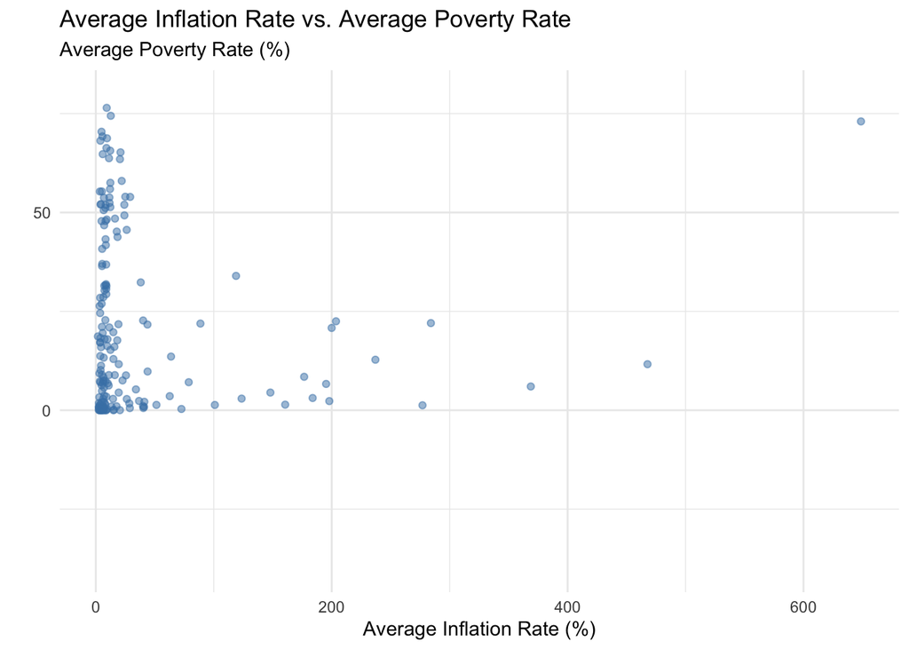

Relationship between average inflation rate and average extreme poverty rate from 1961 to 2023 for each country.

```r
# Clean the dataset to only include one inflation rate and one extreme poverty rate per country
clean_data <- poverty_inflation_data |>
  filter(is.finite(inflation_rate) & is.finite(poverty_rate)) |>
  group_by(country) |>
  summarize(
    avg_inflation_rate = mean(inflation_rate, na.rm = TRUE),
    avg_poverty_rate = mean(poverty_rate, na.rm = TRUE)
  ) |>
  filter(!is.na(avg_inflation_rate) & !is.na(avg_poverty_rate))

# Scatter plot of average inflation rate vs. average poverty rate
ggplot(data = clean_data,
       mapping = aes(x = avg_inflation_rate,
                     y = avg_poverty_rate)) +
  geom_point(alpha = 0.5, color = "steelblue") +
  labs(
    title = "Average Inflation Rate vs. Average Poverty Rate",
    subtitle = "Average Poverty Rate (%)",
    x = "Average Inflation Rate (%)",
    y = "") +
  scale_y_continuous(limits = c(-40, 80)) +
  theme_minimal()
```

After we fit the cleaned data of the average inflation and average poverty rates from 1961 to 2023 for each country to a linear regression model, we get the following statistical outputs.

```r
# Fit the linear regression model
linear_model <- lm(avg_poverty_rate ~ avg_inflation_rate, data = clean_data)

model_summary <- summary(linear_model)
intercept <- coef(linear_model)[1]
slope <- coef(linear_model)[2]
r_squared <- model_summary$r.squared

regression_results <- enframe(c(intercept, slope, r_squared),
                              name = "Term",
                              value = "Value") |>
  mutate(Term = c("Intercept (β0)", "Slope (β1)", "R-squared"))

regression_results |>
  kbl(col.names = c("Term", "Value"),
      align = 'c') |>
  add_header_above(c("Linear Regression Summary" = 2), bold = TRUE, font_size = 20) |>
  row_spec(0, bold = TRUE, font_size = 14, extra_css = "text-align: center;") |>
  column_spec(1:2, extra_css = "text-align: center;") |>
  kable_styling(font_size = 12,
                full_width = FALSE)
```

| Linear Regression Summary Term | Linear Regression Summary Value |
| --- | --- |
| Intercept (β0) | 19.3656423 |
| Slope (β1) | 0.0022242 |
| R-squared | 0.0000624 |

## Evaluating Model Fit

After running a linear regression model, we are interested in accessing how much variability our model accounted for in the response values. We are essentially measuring our model’s success with variance.

We begin with accessing variance in our fitted values, as it represents the amount of variablity in the response that was accounted for by our regression model. The variance in our response variables is the total variability in poverty rates, while the variance in residuals is the unexplained error, or variability.

```r
# Calculate variance components
var_response <- var(clean_data$avg_poverty_rate)
var_fitted <- var(fitted(linear_model))
var_residuals <- var(residuals(linear_model))

# Create a nicely formatted table using kableExtra
variance_table <- data.frame(
  Metric = c("Variance in Response", "Variance in Fitted Values", "Variance in Residuals"),
  Variance = c(var_response, var_fitted, var_residuals)
)

variance_table |>
  kbl(col.names = c("Metric", "Variance"),
      align = 'c') |>
  add_header_above(c("Variance Components in Regression Model" = 2), bold = TRUE, font_size = 20) |>
  row_spec(0, bold = TRUE, font_size = 14, extra_css = "text-align: center;") |>
  column_spec(1:2, extra_css = "text-align: center;") |>
  kable_styling(font_size = 12, full_width = FALSE)
```

| Variance Components in Regression Model Metric | Variance Components in Regression Model Variance |
| --- | --- |
| Variance in Response | 484.824891 |
| Variance in Fitted Values | 0.030231 |
| Variance in Residuals | 484.794661 |

We observe from our $R^2$ = 0.0000624, that our model only explains about 0.00624% of the variance in poverty rate. We can also see that our residual variance is very high, which tells us that much of the variability in poverty rate is left unexplained by inflation. We can conclude that, although there may be some relationship between inflation and poverty rate, inflation alone is an extremely weak predictor of poverty rate, indicating that the quality of our model is very low.

# Simulation

## Visualizing Simulations from the Model

Once we fit and evaluated our model, we simulated our response variable, average poverty rate, to compare the results of our model to that of the observed data.

```r
predictions <- predict(linear_model)

predictions_with_errors <- tibble(predicted_avg_poverty_rate = predictions + rnorm(length(predictions),
                                                                                   mean = 0,
                                                                                   sd = sigma(linear_model)))
```

The scatterplots below illustrate the observed and simulated relationships, respectively, between log-transformed average global inflation rate and average global poverty rate.

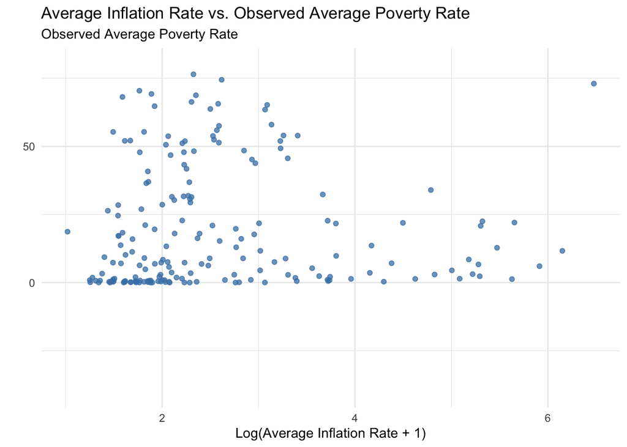

Observed relationship between log-transformed average global inflation rate and average global poverty rate.

```r
# Scatter plot of log-transformed inflation rate vs. poverty rate for clean observed data
ggplot(data = clean_data,
       mapping = aes(x = log1p(avg_inflation_rate),
                     y = avg_poverty_rate)) +
  geom_point(alpha = 0.75, color = "steelblue") +
  labs(title = "Average Inflation Rate vs. Observed Average Poverty Rate",
       x = "Log(Average Inflation Rate + 1)",
       subtitle = "Observed Average Poverty Rate",
       y = "") +
  scale_y_continuous(limits = c(-40, 80)) +
  theme_minimal()
```

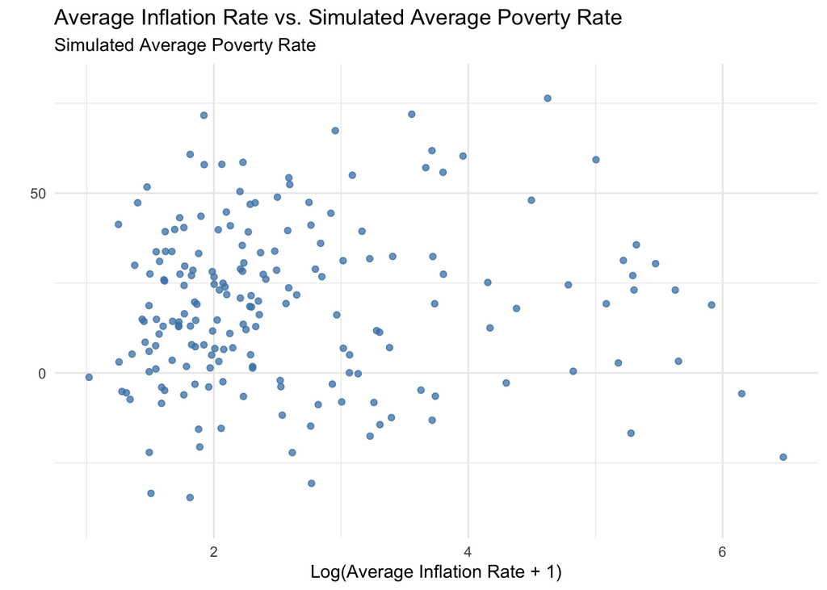

Simulated relationship between log-transformed average global inflation rate and average global poverty rate.

```r
# Construct simulated data
simulated_clean_data <- clean_data |>
  select(avg_inflation_rate) |>
  bind_cols(predictions_with_errors)

# Scatter plot of log-transformed inflation rate vs. poverty rate for clean simulated data
ggplot(data = simulated_clean_data,
       mapping = aes(x = log1p(avg_inflation_rate),
                     y = predicted_avg_poverty_rate)) +
  geom_point(alpha = 0.75, color = "steelblue") +
  labs(title = "Average Inflation Rate vs. Simulated Average Poverty Rate",
       subtitle = "Simulated Average Poverty Rate",
       x = "Log(Average Inflation Rate + 1)",
       y = "") +
  scale_y_continuous(limits = c(-40, 80)) +
  theme_minimal()
```

## Generating Multiple Predictive Checks

Finally, after comparing the observed data to one simulation, we generated 1,000 simulations and plotted the distribution of the $R^2$ values.

```r
# Generate a 1000 simulations
simulations_1000 <- map_dfc(.x = 1:1000,
                            .f = ~tibble(sim = predictions + rnorm(length(predictions), mean = 0, sd = sigma(linear_model))))

# Change column names
colnames(simulations_1000) <- colnames(simulations_1000) |>
  str_replace(pattern = "\\.\\.\\.", replace = "_")

simulations_1000 <- clean_data |>
  filter(!is.na(avg_inflation_rate),
         !is.na(avg_poverty_rate)) |>
  select(avg_poverty_rate) |>
  bind_cols(simulations_1000)

simulations_1000_r_squared <- simulations_1000 |>
  map(~ lm(avg_poverty_rate ~ .x, data = simulations_1000)) |>
  map(glance) |>
  map_dbl(~ .x$r.squared)

simulations_1000_r_squared <- simulations_1000_r_squared[names(simulations_1000_r_squared) != "avg_poverty_rate"]
```

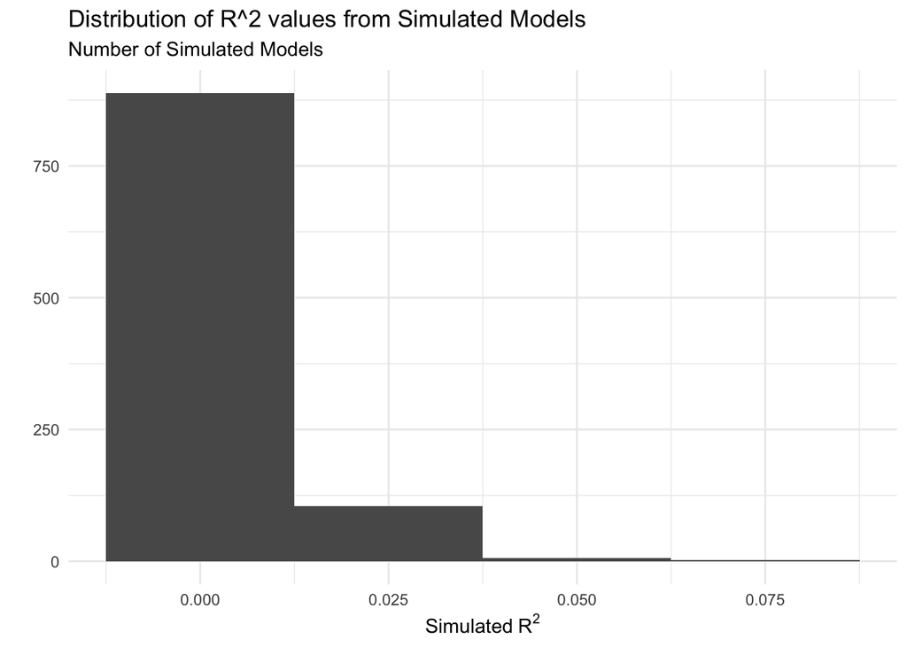

Distribution of R^2 values from the 1,000 simulations of poverty rates based on inflation rate.

```r
tibble(simulations_1000 = simulations_1000_r_squared) |>
  ggplot(aes(x = simulations_1000)) +
  geom_histogram(binwidth = 0.025) +
  labs(title = "Distribution of R^2 values from Simulated Models",
       subtitle = "Number of Simulated Models",
       x = expression("Simulated"~R^2),
       y = "") +
  theme_minimal()
```

The plot above shows that our distribution is heavily skewed to the right, such that our $R^2$ values from the simulations are all very close to 0. This further proves our findings that our linear model does not accurately predict average poverty rate from average inflation rate, as it shows that the data simulated under the linear regression model is very different from what was observed.

# Conclusion

Although a low $R^2$ value and poorly simulated data may seem disappointing, we would like to note that these results actually confirm our initial intuition and hypothesis. We hypothesized that there would be a nonlinear relationship between inflation rates and poverty rates in the world, because economic states of countries are widely sensitive to a multitude of external factors. Regional/country-specific patterns such as economic structures, government policies, and external factors (tariffs and diplomatic conflict) ultimately affect the relationship between inflation and poverty across global regions.

Our findings are largely helpful in our analysis, as our goal was to explore the relationship between inflation rates on poverty rates. We can conclude here that average inflation rates alone are poor predictors of average poverty rates, and there must be additional factors that drive and shrink average inflation rates.

All our code is reproducible at this [Github repository](https://github.com/TarjMecwan/stats331-final-project).

## References

Bank, World. 2022. “Poverty and Inequality Platform (PIP) of the World Bank.” World Bank Group. https://pip.worldbank.org/home.

———. 2025. “Inflation, GDP Deflator (Annual.” World Bank Group. https://data.worldbank.org/indicator/NY.GDP.DEFL.KD.ZG.

Gapminder. 2015. “Extreme Poverty — Data Documentation.” Gapminder. https://www.gapminder.org/data/documentation/epovrate/.

———. 2025. “Gapminder.” Gapminder. https://www.gapminder.org/data/.

OECD. 2022. “Nominal Gross Domestic Product (GDP).” OECD. https://www.oecd.org/en/data/indicators/nominal-gross-domestic-product-gdp.html#:~:text=Gross%20domestic%20product%20(GDP)%20is,country%20during%20a%20certain%20period.